# Gruppe 4

Hier wird 01_Daten einlesen.rmd eingebunden

# Daten einlesen

Daten werden im Hintergrund hier eingelesen.

```r
#Anzeigen, welche Variablen in den Datensätzen sind (ohne weitere Information , nur Name)
#names(umsatzdaten)
#names(kiwo)
#names(wetter)
#Mehr Informationen zu den Datensätzen anzeigen
skim(umsatzdaten)
```

Data summary

| Name | umsatzdaten |
| --- | --- |
| Number of rows | 10899 |
| Number of columns | 4 |
| _______________________ |  |
| Column type frequency: |  |
| Date | 1 |
| factor | 2 |
| numeric | 1 |
| ________________________ |  |
| Group variables | None |

**Variable type: Date**

| skim_variable | n_missing | complete_rate | min | max | median | n_unique |
| --- | --- | --- | --- | --- | --- | --- |
| Datum | 0 | 1 | 2013-07-01 | 2019-06-06 | 2016-06-17 | 2121 |

**Variable type: factor**

| skim_variable | n_missing | complete_rate | ordered | n_unique | top_counts |
| --- | --- | --- | --- | --- | --- |
| Warengruppe | 0 | 1 | FALSE | 6 | Bro: 2121, Bro: 2121, Cro: 2121, Kuc: 2121 |
| Wochentag | 0 | 1 | FALSE | 7 | Son: 1570, Don: 1568, Sam: 1564, Die: 1562 |

**Variable type: numeric**

| skim_variable | n_missing | complete_rate | mean | sd | p0 | p25 | p50 | p75 | p100 | hist |
| --- | --- | --- | --- | --- | --- | --- | --- | --- | --- | --- |
| Umsatz | 0 | 1 | 206.66 | 142.81 | 7.05 | 97.53 | 163.3 | 280.81 | 1879.46 | ▇▁▁▁▁ |

```r
skim(wetter)
```

Data summary

| Name | wetter |
| --- | --- |
| Number of rows | 2601 |
| Number of columns | 5 |
| _______________________ |  |
| Column type frequency: |  |
| Date | 1 |
| numeric | 4 |
| ________________________ |  |
| Group variables | None |

**Variable type: Date**

| skim_variable | n_missing | complete_rate | min | max | median | n_unique |
| --- | --- | --- | --- | --- | --- | --- |
| Datum | 0 | 1 | 2012-01-01 | 2019-08-01 | 2015-12-24 | 2601 |

**Variable type: numeric**

| skim_variable | n_missing | complete_rate | mean | sd | p0 | p25 | p50 | p75 | p100 | hist |
| --- | --- | --- | --- | --- | --- | --- | --- | --- | --- | --- |
| Bewoelkung | 10 | 1.00 | 4.81 | 2.58 | 0.00 | 3.00 | 6 | 7.00 | 8.00 | ▃▂▂▆▇ |
| Temperatur | 0 | 1.00 | 12.10 | 7.17 | -10.25 | 6.51 | 12 | 17.82 | 32.67 | ▁▆▇▇▁ |
| Windgeschwindigkeit | 0 | 1.00 | 11.19 | 4.12 | 3.00 | 8.00 | 10 | 14.00 | 35.00 | ▆▇▂▁▁ |
| Wettercode | 669 | 0.74 | 37.48 | 27.57 | 0.00 | 10.00 | 28 | 61.00 | 95.00 | ▆▃▁▇▁ |

```r
skim(kiwo)
```

Data summary

| Name | kiwo |
| --- | --- |
| Number of rows | 72 |
| Number of columns | 2 |
| _______________________ |  |
| Column type frequency: |  |
| Date | 1 |
| numeric | 1 |
| ________________________ |  |
| Group variables | None |

**Variable type: Date**

| skim_variable | n_missing | complete_rate | min | max | median | n_unique |
| --- | --- | --- | --- | --- | --- | --- |
| Datum | 0 | 1 | 2012-06-16 | 2019-06-30 | 2015-12-23 | 72 |

**Variable type: numeric**

| skim_variable | n_missing | complete_rate | mean | sd | p0 | p25 | p50 | p75 | p100 | hist |
| --- | --- | --- | --- | --- | --- | --- | --- | --- | --- | --- |
| KielerWoche | 0 | 1 | 1 | 0 | 1 | 1 | 1 | 1 | 1 | ▁▁▇▁▁ |

```r
#Beobachtung: Bewoelkung hat fehlende Werte.
```

# Daten zusammenfügen

```r
umsatzdaten_kiwo<-left_join(umsatzdaten,kiwo, by="Datum")
#names(umsatzdaten_kiwo)
umsatzdaten_kiwo_wetter<-left_join(umsatzdaten_kiwo , wetter, by="Datum")
#names(umsatzdaten_kiwo_wetter)

write.csv(umsatzdaten_kiwo_wetter,file.path('Daten','umsatzdaten_kiwo_wetter.csv',fsep = .Platform$file.sep))
```

Hier wird 04_Daten_neuevar_feiertage.Rmd eingebunden

```r
# Einlesen der Feiertage

library(jsonlite)
# url mit den Kalenderdaten zu Feiertagen
url1 <- "https://feiertage-api.de/api/?jahr=2013&nur_land=SH"
url2 <- "https://feiertage-api.de/api/?jahr=2014&nur_land=SH"
url3 <- "https://feiertage-api.de/api/?jahr=2015&nur_land=SH"
url4 <- "https://feiertage-api.de/api/?jahr=2016&nur_land=SH"
url5 <- "https://feiertage-api.de/api/?jahr=2017&nur_land=SH"
url6 <- "https://feiertage-api.de/api/?jahr=2018&nur_land=SH"
url7 <- "https://feiertage-api.de/api/?jahr=2019&nur_land=SH"
```

```r
# url lesen und data.frame erzeugen
feiertage13 <- fromJSON(txt=url1)
feiertage14 <- fromJSON(txt=url2)
feiertage15 <- fromJSON(txt=url3)
feiertage16 <- fromJSON(txt=url4)
feiertage17 <- fromJSON(txt=url5)
feiertage18 <- fromJSON(txt=url6)
feiertage19 <- fromJSON(txt=url7)
```

```r
feiertage13_tbl <- as_data_frame(feiertage13) #data frame erzeugen
feiertage14_tbl <- as_data_frame(feiertage14) #data frame erzeugen
feiertage15_tbl <- as_data_frame(feiertage15) #data frame erzeugen
feiertage16_tbl <- as_data_frame(feiertage16) #data frame erzeugen
feiertage17_tbl <- as_data_frame(feiertage17) #data frame erzeugen
feiertage18_tbl <- as_data_frame(feiertage18) #data frame erzeugen
feiertage19_tbl <- as_data_frame(feiertage19) #data frame erzeugen
```

```r
#führt die Datentabellen zusammen
feiertage13_14_tbl<-full_join(feiertage13_tbl, feiertage14_tbl)
feiertage13_14_15_tbl<-full_join(feiertage13_14_tbl, feiertage15_tbl)
feiertage13_14_15_16_tbl<-full_join(feiertage13_14_15_tbl, feiertage16_tbl)
feiertage13_14_15_16_17_tbl<-full_join(feiertage13_14_15_16_tbl,
                                       feiertage17_tbl)
feiertage13_14_15_16_17_18_tbl<-full_join(feiertage13_14_15_16_17_tbl,
                                          feiertage18_tbl)
feiertage13_14_15_16_17_18_19_tbl<-full_join(feiertage13_14_15_16_17_18_tbl,
                                             feiertage19_tbl)
# Datensatz umstrukturiert von "wide" mit mehreren Spalten auf "long", um die Daten konform zu unseren anderen Daten zu strukturieren. Umformung mit tidyverse-package. Zur Übergabe des Ergebnisses neue Variable feiertage_neu geschrieben

feiertage_neu <- feiertage13_14_15_16_17_18_19_tbl %>%
  pivot_longer(everything(), names_to = "Feiertage", values_to = "Datum")
```

Anmerkung AL: der folgende Move schreibt in dei Variablen NA als Wert, setzt sie aber nicht auf fehlend, deswegen auskommentiert

```r
# Fehlende Werte "" = Leerzeichen und "NULL" durch "NA" in Datensatz ersetzt

#feiertage_neu$Datum[feiertage_neu$Datum == ""] <-NA
#feiertage_neu$Datum[feiertage_neu$Datum == "NULL"] <-NA
```

Alternative AL:

- Konvertiere die Strings gleich in Daten… und dabei wird alles auf missings (NA) gesetzt, was kein Datum ist. Filtere dann so, dass die Fälle mit leeren Datumsangaben rausfallen

```r
feiertage_neu$Datum<- ymd(feiertage_neu$Datum)
feiertage_neu<- feiertage_neu%>%
  filter(!is.na(Datum))
feiertage_neu$istFeiertag<-1
```

Hier wird 02_Data_cleaning.rmd eingebunden

# Datenstruktur und Missings

```r
skim(umsatzdaten_kiwo_wetter)
```

Data summary

| Name | umsatzdaten_kiwo_wetter |
| --- | --- |
| Number of rows | 10899 |
| Number of columns | 9 |
| _______________________ |  |
| Column type frequency: |  |
| Date | 1 |
| factor | 2 |
| numeric | 6 |
| ________________________ |  |
| Group variables | None |

**Variable type: Date**

| skim_variable | n_missing | complete_rate | min | max | median | n_unique |
| --- | --- | --- | --- | --- | --- | --- |
| Datum | 0 | 1 | 2013-07-01 | 2019-06-06 | 2016-06-17 | 2121 |

**Variable type: factor**

| skim_variable | n_missing | complete_rate | ordered | n_unique | top_counts |
| --- | --- | --- | --- | --- | --- |
| Warengruppe | 0 | 1 | FALSE | 6 | Bro: 2121, Bro: 2121, Cro: 2121, Kuc: 2121 |
| Wochentag | 0 | 1 | FALSE | 7 | Son: 1570, Don: 1568, Sam: 1564, Die: 1562 |

**Variable type: numeric**

| skim_variable | n_missing | complete_rate | mean | sd | p0 | p25 | p50 | p75 | p100 | hist |
| --- | --- | --- | --- | --- | --- | --- | --- | --- | --- | --- |
| Umsatz | 0 | 1.00 | 206.66 | 142.81 | 7.05 | 97.53 | 163.30 | 280.81 | 1879.46 | ▇▁▁▁▁ |
| KielerWoche | 10676 | 0.02 | 1.00 | 0.00 | 1.00 | 1.00 | 1.00 | 1.00 | 1.00 | ▁▁▇▁▁ |
| Bewoelkung | 135 | 0.99 | 4.73 | 2.65 | 0.00 | 3.00 | 6.00 | 7.00 | 8.00 | ▃▂▂▅▇ |
| Temperatur | 81 | 0.99 | 11.82 | 7.15 | -8.47 | 6.11 | 11.26 | 17.62 | 32.67 | ▁▇▇▆▁ |
| Windgeschwindigkeit | 81 | 0.99 | 11.00 | 4.14 | 3.00 | 8.00 | 10.00 | 13.00 | 35.00 | ▇▇▂▁▁ |
| Wettercode | 2602 | 0.76 | 36.16 | 27.04 | 0.00 | 10.00 | 22.00 | 61.00 | 95.00 | ▆▃▁▇▁ |

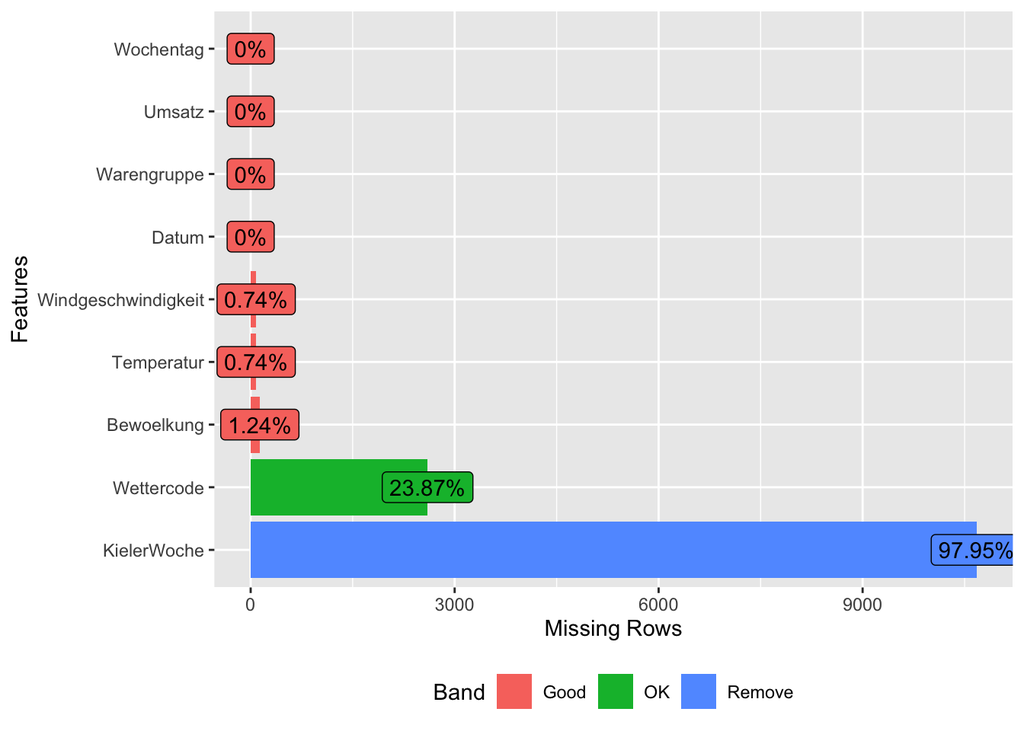

```r
# Wir haben 10899 Umsatzdatensätze von 2121 Tagen. Wir bekommen durch fehlende Wetterdaten (besonders: 669 fehlende Wettercodes) insgesamt 2602 Datensätze ohne Wettercode--> Wenn wir also alle Datensätze fallen lassen, die hier fehlende Daten haben, reduzieren wir die Datenbasis erheblich

library(DataExplorer)
plot_missing(umsatzdaten_kiwo_wetter)
```

# Analyse der Ausreißer

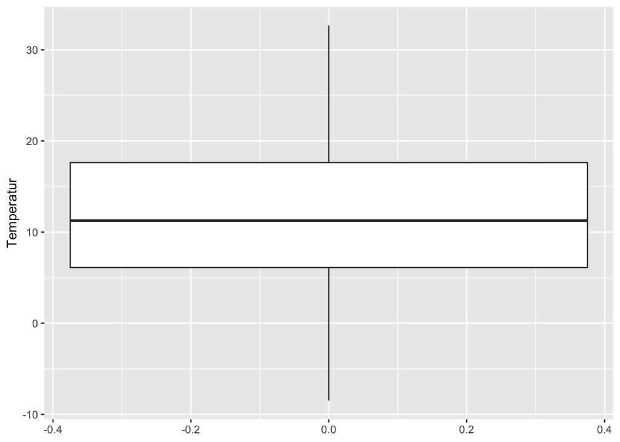

```r
ggplot(umsatzdaten_kiwo_wetter) + geom_boxplot(aes(y=Temperatur),outlier.colour="red")+ coord_cartesian(ylim = c(min(umsatzdaten_kiwo_wetter$Temperatur), max(umsatzdaten_kiwo_wetter$Temperatur)))
```

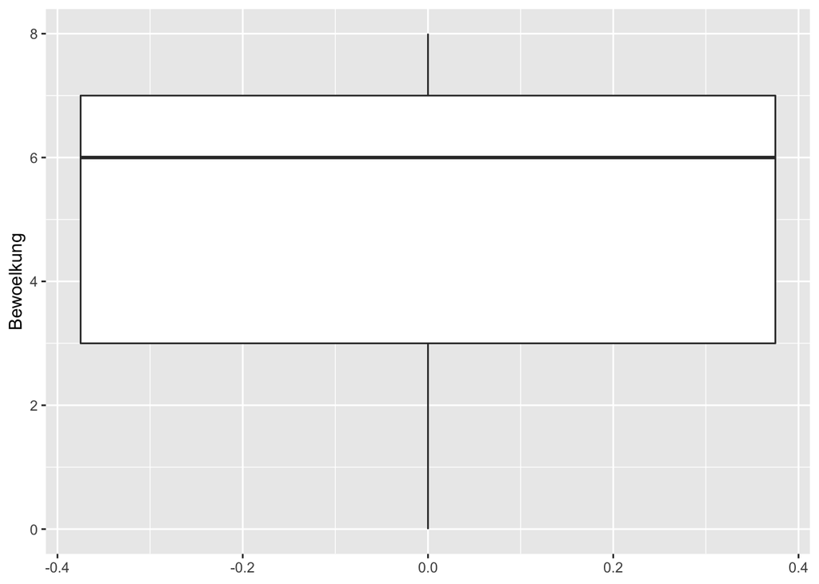

```r
ggplot(umsatzdaten_kiwo_wetter) + geom_boxplot(aes(y=Bewoelkung),outlier.colour="red")+ coord_cartesian(ylim = c(min(umsatzdaten_kiwo_wetter$Bewoelkung), max(umsatzdaten_kiwo_wetter$Bewoelkung)))
```

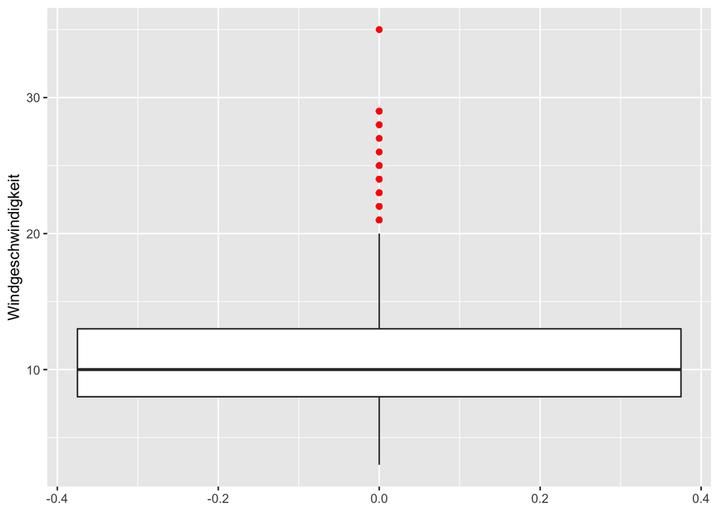

```r
ggplot(umsatzdaten_kiwo_wetter) + geom_boxplot(aes(y=Windgeschwindigkeit),outlier.colour="red")+ coord_cartesian(ylim = c(min(umsatzdaten_kiwo_wetter$Windgeschwindigkeit), max(umsatzdaten_kiwo_wetter$Windgeschwindigkeit)))
```

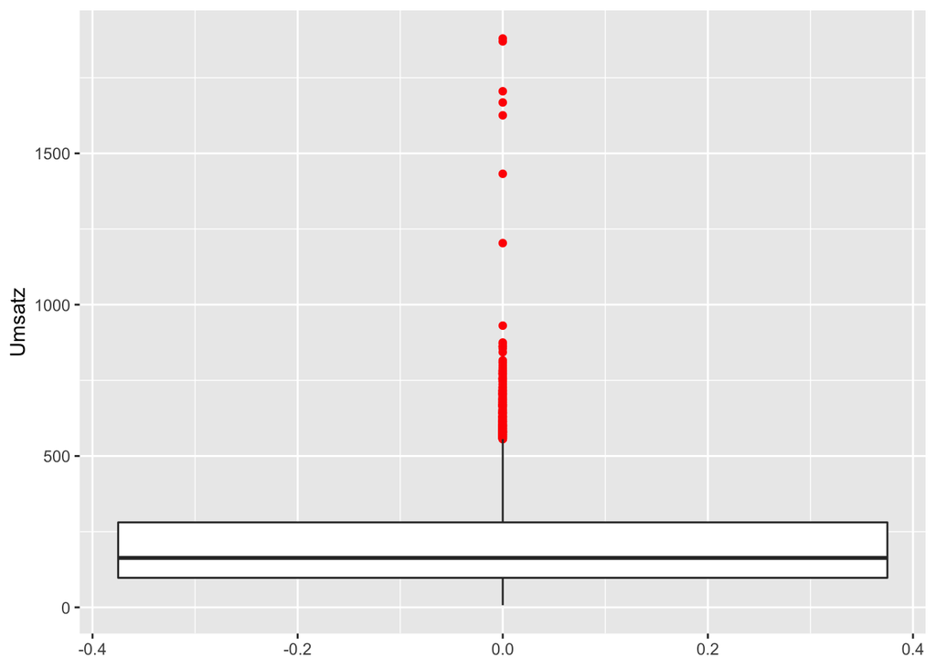

```r
# Windgeschwindigkeit hat ein paar Ausreißer, der Rest ok
ggplot(umsatzdaten_kiwo_wetter) + geom_boxplot(aes(y=Umsatz),outlier.colour="red")+ coord_cartesian(ylim = c(min(umsatzdaten_kiwo_wetter$Umsatz), max(umsatzdaten_kiwo_wetter$Umsatz)))
```